# COMPSCIX 415.2 Homework 5/Midterm

Pankaj Mittal

July 5, 2018

My Github repository for my assignments can be found at this URL: https://github.com/pankajmit/compscix-415-2-assignments.git

```r
library(mdsr)
library(ggplot2)
library(tidyverse)
library(nycflights13)
```

## Table of Contents

1. RStudio and R Markdown
2. The tidyverse packages
3. R Basics
4. Data Import / Export
5. Visualization
6. EDA

## R Studio and R Markdown

### Each midterm question is clearly separated in this document with table cof content shown above

## The tidyverse packages

### Question 1: Name which package is associated with each task below?

#### Plotting - ggplot2

#### Data munging/wrangling - dplyr

#### Importing/Exporting data - readr

### Question 2: Name two functions from each package?

#### Plotting (ggplot2) - geom_point, geom_boxplot

#### Data munging/wrangling (dplyr) - select, filter, summarise, mutate

#### Reshaping Data(tidyr) - gather, spread

#### Importing/Exporting data (readr) - read_csv, read_delim, write_csv

## R Basics

### Question 1: Fix the code with fewest number of possible changes?

#### Corrected code is below:

```r
My_data.name___is.too00ooLong <- c( 1 , 2 , 3 )
My_data.name___is.too00ooLong
```

```
## [1] 1 2 3
```

### Question 2: Fix the code so it works?

#### Corrected code is below

```r
my_string <- c('has', 'an', 'error', 'in', 'it')
my_string
```

```
## [1] "has"   "an"    "error" "in"    "it"
```

### Question 3: Comment on what happened to the vector?

#### Answer: All entries for the vector were forced to convert to character

```r
my_vector <- c(1, 2, '3', '4', 5)
my_vector
```

```
## [1] "1" "2" "3" "4" "5"
```

```r
is.character(my_vector)
```

```
## [1] TRUE
```

```r
is.double(my_vector)
```

```
## [1] FALSE
```

## Data import/export

### Question 1: Showcase import of rail_trail.txt file

```r
file_path_read <- "C:/training/rail_trail.txt"
x <- read_delim(file = file_path_read, delim = "|")
glimpse(x)
```

```
## Observations: 90
## Variables: 10
## $ hightemp   <int> 83, 73, 74, 95, 44, 69, 66, 66, 80, 79, 78, 65, 41,...
## $ lowtemp    <int> 50, 49, 52, 61, 52, 54, 39, 38, 55, 45, 55, 48, 49,...
## $ avgtemp    <dbl> 66.5, 61.0, 63.0, 78.0, 48.0, 61.5, 52.5, 52.0, 67....
## $ spring     <int> 0, 0, 1, 0, 1, 1, 1, 1, 0, 0, 0, 1, 1, 0, 0, 1, 0, ...
## $ summer     <int> 1, 1, 0, 1, 0, 0, 0, 0, 1, 1, 1, 0, 0, 0, 0, 0, 1, ...
## $ fall       <int> 0, 0, 0, 0, 0, 0, 0, 0, 0, 0, 0, 0, 0, 1, 1, 0, 0, ...
## $ cloudcover <dbl> 7.6, 6.3, 7.5, 2.6, 10.0, 6.6, 2.4, 0.0, 3.8, 4.1, ...
## $ precip     <dbl> 0.00, 0.29, 0.32, 0.00, 0.14, 0.02, 0.00, 0.00, 0.0...
## $ volume     <int> 501, 419, 397, 385, 200, 375, 417, 629, 533, 547, 4...
## $ weekday    <int> 1, 1, 1, 0, 1, 1, 1, 0, 0, 1, 1, 1, 1, 1, 1, 1, 0, ...
```

### Question 2: Showcase export of rail_trail.txt file

```r
file_path_write <- "C:/training/rail_trail.csv"
write_csv(x, path = file_path_write)
y <- read_csv(file = file_path_write)
glimpse(y)
```

```
## Observations: 90
## Variables: 10
## $ hightemp   <int> 83, 73, 74, 95, 44, 69, 66, 66, 80, 79, 78, 65, 41,...
## $ lowtemp    <int> 50, 49, 52, 61, 52, 54, 39, 38, 55, 45, 55, 48, 49,...
## $ avgtemp    <dbl> 66.5, 61.0, 63.0, 78.0, 48.0, 61.5, 52.5, 52.0, 67....
## $ spring     <int> 0, 0, 1, 0, 1, 1, 1, 1, 0, 0, 0, 1, 1, 0, 0, 1, 0, ...
## $ summer     <int> 1, 1, 0, 1, 0, 0, 0, 0, 1, 1, 1, 0, 0, 0, 0, 0, 1, ...
## $ fall       <int> 0, 0, 0, 0, 0, 0, 0, 0, 0, 0, 0, 0, 0, 1, 1, 0, 0, ...
## $ cloudcover <dbl> 7.6, 6.3, 7.5, 2.6, 10.0, 6.6, 2.4, 0.0, 3.8, 4.1, ...
## $ precip     <dbl> 0.00, 0.29, 0.32, 0.00, 0.14, 0.02, 0.00, 0.00, 0.0...
## $ volume     <int> 501, 419, 397, 385, 200, 375, 417, 629, 533, 547, 4...
## $ weekday    <int> 1, 1, 1, 0, 1, 1, 1, 0, 0, 1, 1, 1, 1, 1, 1, 1, 0, ...
```

## Visualization

#### 1. This data is better represented as bar chart rather than bubble chart

#### 2. Percentages are not adding up to 100. Those should have been explained

#### 3. It would have been better to see the age breakup for men and women rather than completely separate visual

### Question 2: Reproduce the graphic shown using *diamonds* data set

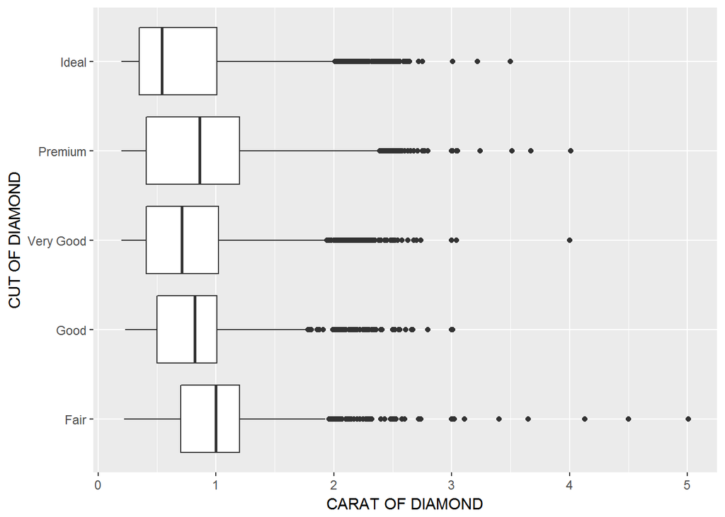

```r
ggplot(data = diamonds, mapping = aes(x = cut, y = carat)) +
  geom_boxplot() +
  labs(x = "CUT OF DIAMOND", y = "CARAT OF DIAMOND") +
  coord_flip()
```

### Question 3: How to make above graphic more useful

#### Answer: This graphic could be more useful if box plot is drawn separately for each color, rarther than putting together.

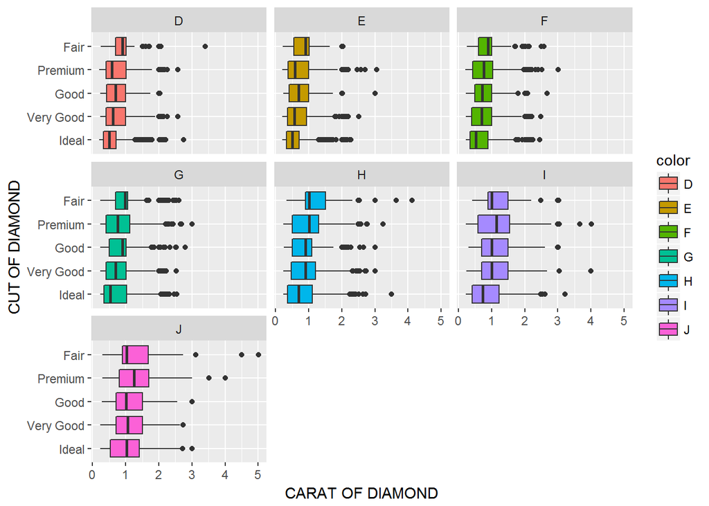

```r
ggplot(data = diamonds, mapping = aes(x = reorder(cut, carat, FUN = median), y = carat, fill=color)) +
  geom_boxplot() +
  labs(x = "CUT OF DIAMOND", y = "CARAT OF DIAMOND") +
  coord_flip() +
  facet_wrap(~color)
```

## Data Munging and Wrangling

### Question 1: Is this data tidy?

#### No, this data is not tidy. Below code will make this tidy.

```r
table2 %>%
  spread(key = type, value = count)
```

```
## # A tibble: 6 x 4
##   country      year  cases population
##   <chr>       <int>  <int>      <int>
## 1 Afghanistan  1999    745   19987071
## 2 Afghanistan  2000   2666   20595360
## 3 Brazil       1999  37737  172006362
## 4 Brazil       2000  80488  174504898
## 5 China        1999 212258 1272915272
## 6 China        2000 213766 1280428583
```

### Question 2: Create a new column called price_per_carat? Do not print the results

#### Here is the code

```r
diamonds %>%
  mutate(price_per_carat = price / carat)
```

### Question 3: How many diamond (and what proportion) have price > 10000 and a carat < 1.5?

#### Answer: 834 diamonds with about 1.54% proportion

```r
diamonds %>%
  mutate(selected = (price > 10000 & carat < 1.5)) %>%
  group_by(selected) %>%
  summarise(n = n()) %>%
  mutate(prop = n/sum(n))
```

```
## # A tibble: 2 x 3
##   selected     n   prop
##   <lgl>    <int>  <dbl>
## 1 FALSE    53106 0.985
## 2 TRUE       834 0.0155
```

#### We just need to be careful of NULL values in the data

## Exploratory Data Analysis (txhousing data)

### Question 1: During what time period is the data from?

```r
txhousing %>%
  summarize(min_year = min(year), min_mo = min(month), max_year = max(year), max_mo = max(month))
```

```
## # A tibble: 1 x 4
##   min_year min_mo max_year max_mo
##      <int>  <int>    <int>  <int>
## 1     2000      1     2015     12
```

### Question 2: How many cities are represented?

#### Answer: 46 cities are represented

```r
txhousing %>%
  count(city)
```

```
## # A tibble: 46 x 2
##    city                      n
##    <chr>                 <int>
##  1 Abilene                 187
##  2 Amarillo                187
##  3 Arlington               187
##  4 Austin                  187
##  5 Bay Area                187
##  6 Beaumont                187
##  7 Brazoria County         187
##  8 Brownsville             187
##  9 Bryan-College Station   187
## 10 Collin County           187
## # ... with 36 more rows
```

### Question 3: Which city, month and year had the highest number of sales?

#### Answer: City = Houston, Month = 7 (July), Year = 2015

```r
txhousing %>%
  filter(sales == max(sales, na.rm = TRUE))
```

```
## # A tibble: 1 x 9
##   city     year month sales     volume median listings inventory  date
##   <chr>   <int> <int> <dbl>      <dbl>  <dbl>    <dbl>     <dbl> <dbl>
## 1 Houston  2015     7  8945 2568156780 217600    23875       3.4 2016.
```

### Question 4: What kind of relationship exists between the number of listings and the number of sales?

#### Answer: In general, as number of listings increases, number of sales is also increasing

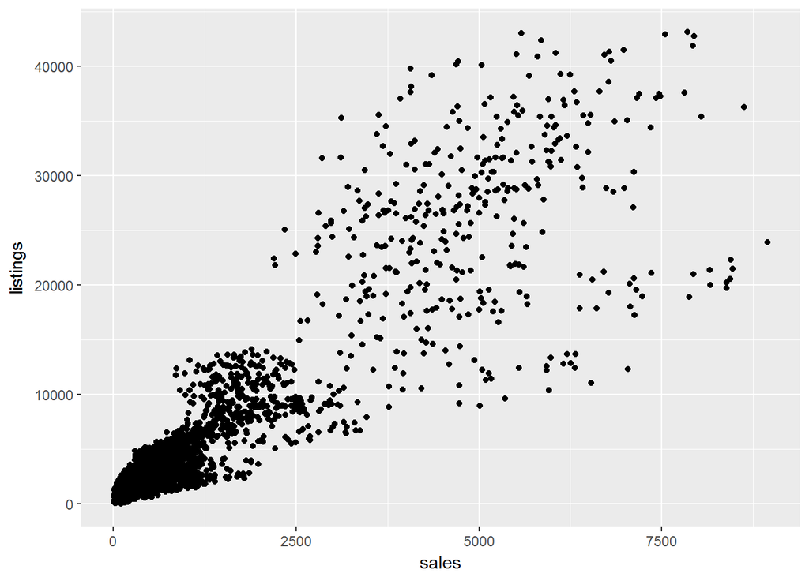

```r
ggplot(data = txhousing, aes(sales, listings)) +
  geom_point()
```

### Question 5: What proportion of sales is missing for each city?

#### Answer: Please see the results of query below

```r
txhousing %>%
  mutate(missed_sales = is.na(sales)) %>%
  group_by(city, missed_sales) %>%
  summarise(count = n()) %>%
  mutate(prop = count / sum(count))
```

```
## # A tibble: 66 x 4
## # Groups:   city [46]
##    city            missed_sales count   prop
##    <chr>           <lgl>        <int>  <dbl>
##  1 Abilene         FALSE          187 1
##  2 Amarillo        FALSE          187 1
##  3 Arlington       FALSE          187 1
##  4 Austin          FALSE          187 1
##  5 Bay Area        FALSE          187 1
##  6 Beaumont        FALSE          187 1
##  7 Brazoria County FALSE          173 0.925
##  8 Brazoria County TRUE            14 0.0749
##  9 Brownsville     FALSE          185 0.989
## 10 Brownsville     TRUE             2 0.0107
## # ... with 56 more rows
```

### Question 6: Look at only the cities and months with greater than 500 sales

```r
txhousing_over500 <- txhousing %>%
  filter(sales > 500)
txhousing_over500
```

```
## # A tibble: 1,883 x 9
##    city       year month sales   volume median listings inventory  date
##    <chr>     <int> <int> <dbl>    <dbl>  <dbl>    <dbl>     <dbl> <dbl>
##  1 Arlington  2000     8   507 60875199 103400     1417       3.5 2001.
##  2 Arlington  2001     5   536 69878959 114400     1592       3.7 2001.
##  3 Arlington  2001     6   534 67744182 108500     1627       3.8 2001.
##  4 Arlington  2001     8   505 65080743 113600     1616       3.7 2002.
##  5 Arlington  2002     5   503 67240236 116100     1741       3.9 2002.
##  6 Arlington  2002     7   509 66954143 119100     1925       4.4 2002.
##  7 Arlington  2003     5   502 67131982 118000     2544       5.9 2003.
##  8 Arlington  2003     7   524 73194692 123500     2799       6.5 2004.
##  9 Arlington  2003     8   531 72397143 123900     2801       6.4 2004.
## 10 Arlington  2004     5   527 72401436 118300     2922       6.5 2004.
## # ... with 1,873 more rows
```

#### 6)a) Are the distributions of the median sales price, when grouped by city, different?

#### Answer: distribution of median sales price is different as per chart below

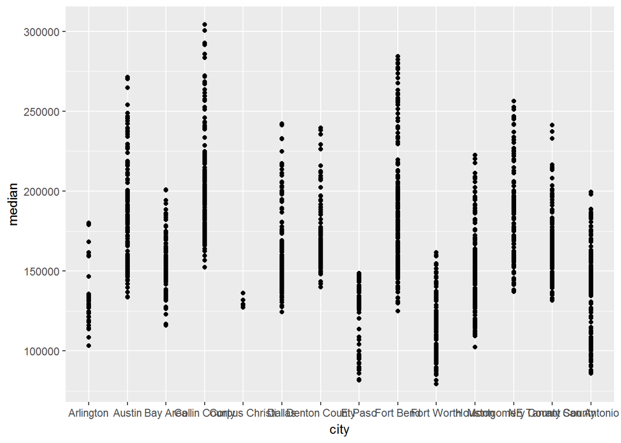

```r
ggplot(data = txhousing_over500, mapping = aes(x = city, y = median)) +
  geom_point()
```

#### 6)b) Any cities that stand out that you’d want to investigate further?

#### Answer: Houston has wide range of sales; Dallas has too many ouliers on the higher median price

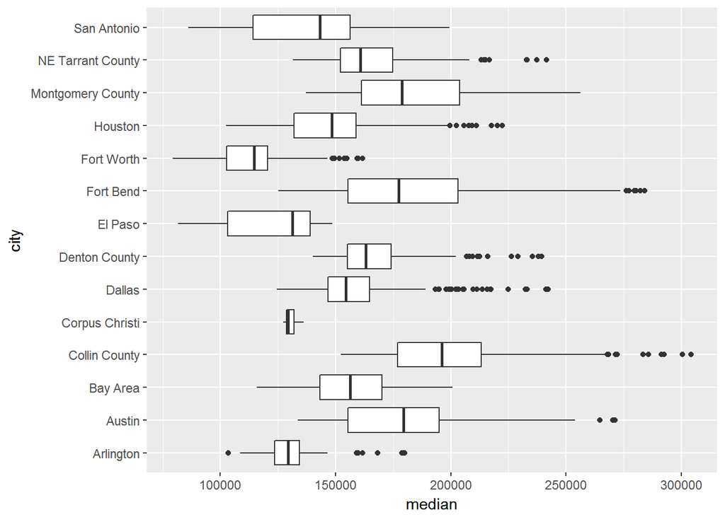

```r
ggplot(data = txhousing_over500, mapping = aes(x = city, y = median)) +
  geom_boxplot() +
  coord_flip()
```

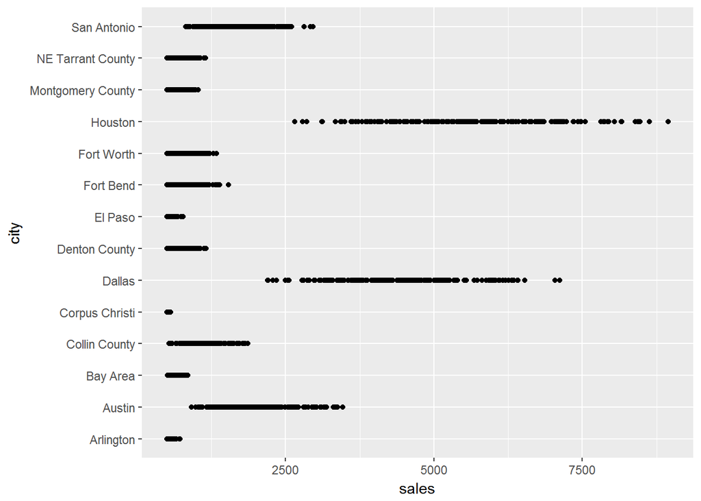

```r
ggplot(data = txhousing_over500, mapping = aes(x = city, y = sales)) +
  geom_point() +
  coord_flip()
```

#### 6)c) Why might we want to filter out all cities and months with sales less than 500?

#### Answer: This makes the data set targeted for our analysis without the need of any filtering

# COMPSCIX 415.2 Homework 5/Midterm

Pankaj Mittal

July 5, 2018

My Github repository for my assignments can be found at this URL: https://github.com/pankajmit/compscix-415-2-assignments.git

```r
library(mdsr)
library(ggplot2)
library(tidyverse)
library(nycflights13)
```

## Table of Contents

1. RStudio and R Markdown
2. The tidyverse packages
3. R Basics
4. Data Import / Export
5. Visualization
6. EDA

## R Studio and R Markdown

### Each midterm question is clearly separated in this document with table cof content shown above

## The tidyverse packages

### Question 1: Name which package is associated with each task below?

#### Plotting - ggplot2

#### Data munging/wrangling - dplyr

#### Importing/Exporting data - readr

### Question 2: Name two functions from each package?

#### Plotting (ggplot2) - geom_point, geom_boxplot

#### Data munging/wrangling (dplyr) - select, filter, summarise, mutate

#### Reshaping Data(tidyr) - gather, spread

#### Importing/Exporting data (readr) - read_csv, read_delim, write_csv

## R Basics

### Question 1: Fix the code with fewest number of possible changes?

#### Corrected code is below:

```r
My_data.name___is.too00ooLong <- c( 1 , 2 , 3 )
My_data.name___is.too00ooLong
```

```
## [1] 1 2 3
```

### Question 2: Fix the code so it works?

#### Corrected code is below

```r
my_string <- c('has', 'an', 'error', 'in', 'it')
my_string
```

```
## [1] "has"   "an"    "error" "in"    "it"
```

### Question 3: Comment on what happened to the vector?

#### Answer: All entries for the vector were forced to convert to character

```r
my_vector <- c(1, 2, '3', '4', 5)
my_vector
```

```
## [1] "1" "2" "3" "4" "5"
```

```r
is.character(my_vector)
```

```
## [1] TRUE
```

```r
is.double(my_vector)
```

```
## [1] FALSE
```

## Data import/export

### Question 1: Showcase import of rail_trail.txt file

```r
file_path_read <- "C:/training/rail_trail.txt"
x <- read_delim(file = file_path_read, delim = "|")
glimpse(x)
```

```
## Observations: 90
## Variables: 10
## $ hightemp   <int> 83, 73, 74, 95, 44, 69, 66, 66, 80, 79, 78, 65, 41,...
## $ lowtemp    <int> 50, 49, 52, 61, 52, 54, 39, 38, 55, 45, 55, 48, 49,...
## $ avgtemp    <dbl> 66.5, 61.0, 63.0, 78.0, 48.0, 61.5, 52.5, 52.0, 67....
## $ spring     <int> 0, 0, 1, 0, 1, 1, 1, 1, 0, 0, 0, 1, 1, 0, 0, 1, 0, ...
## $ summer     <int> 1, 1, 0, 1, 0, 0, 0, 0, 1, 1, 1, 0, 0, 0, 0, 0, 1, ...
## $ fall       <int> 0, 0, 0, 0, 0, 0, 0, 0, 0, 0, 0, 0, 0, 1, 1, 0, 0, ...
## $ cloudcover <dbl> 7.6, 6.3, 7.5, 2.6, 10.0, 6.6, 2.4, 0.0, 3.8, 4.1, ...
## $ precip     <dbl> 0.00, 0.29, 0.32, 0.00, 0.14, 0.02, 0.00, 0.00, 0.0...
## $ volume     <int> 501, 419, 397, 385, 200, 375, 417, 629, 533, 547, 4...
## $ weekday    <int> 1, 1, 1, 0, 1, 1, 1, 0, 0, 1, 1, 1, 1, 1, 1, 1, 0, ...
```

### Question 2: Showcase export of rail_trail.txt file

```r
file_path_write <- "C:/training/rail_trail.csv"
write_csv(x, path = file_path_write)
y <- read_csv(file = file_path_write)
glimpse(y)
```

```
## Observations: 90
## Variables: 10
## $ hightemp   <int> 83, 73, 74, 95, 44, 69, 66, 66, 80, 79, 78, 65, 41,...
## $ lowtemp    <int> 50, 49, 52, 61, 52, 54, 39, 38, 55, 45, 55, 48, 49,...
## $ avgtemp    <dbl> 66.5, 61.0, 63.0, 78.0, 48.0, 61.5, 52.5, 52.0, 67....
## $ spring     <int> 0, 0, 1, 0, 1, 1, 1, 1, 0, 0, 0, 1, 1, 0, 0, 1, 0, ...
## $ summer     <int> 1, 1, 0, 1, 0, 0, 0, 0, 1, 1, 1, 0, 0, 0, 0, 0, 1, ...
## $ fall       <int> 0, 0, 0, 0, 0, 0, 0, 0, 0, 0, 0, 0, 0, 1, 1, 0, 0, ...
## $ cloudcover <dbl> 7.6, 6.3, 7.5, 2.6, 10.0, 6.6, 2.4, 0.0, 3.8, 4.1, ...
## $ precip     <dbl> 0.00, 0.29, 0.32, 0.00, 0.14, 0.02, 0.00, 0.00, 0.0...
## $ volume     <int> 501, 419, 397, 385, 200, 375, 417, 629, 533, 547, 4...
## $ weekday    <int> 1, 1, 1, 0, 1, 1, 1, 0, 0, 1, 1, 1, 1, 1, 1, 1, 0, ...
```

## Visualization

#### 1. This data is better represented as bar chart rather than bubble chart

#### 2. Percentages are not adding up to 100. Those should have been explained

#### 3. It would have been better to see the age breakup for men and women rather than completely separate visual

### Question 2: Reproduce the graphic shown using *diamonds* data set

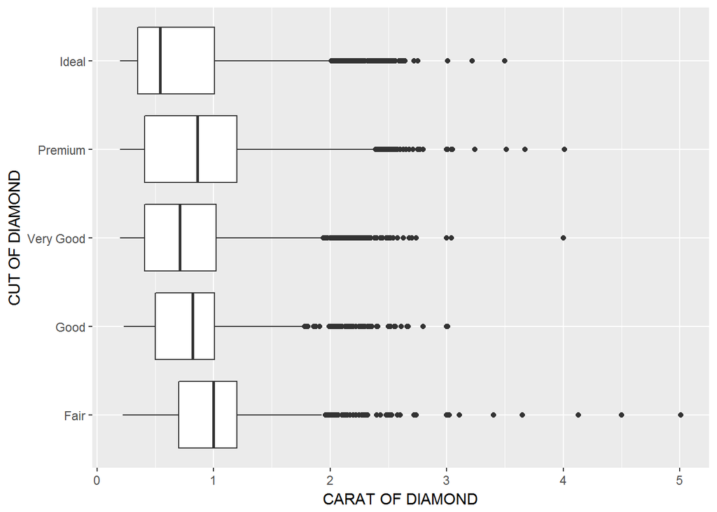

```r
ggplot(data = diamonds, mapping = aes(x = cut, y = carat)) +
  geom_boxplot() +
  labs(x = "CUT OF DIAMOND", y = "CARAT OF DIAMOND") +
  coord_flip()
```

### Question 3: How to make above graphic more useful

#### Answer: This graphic could be more useful if box plot is drawn separately for each color, rarther than putting together.

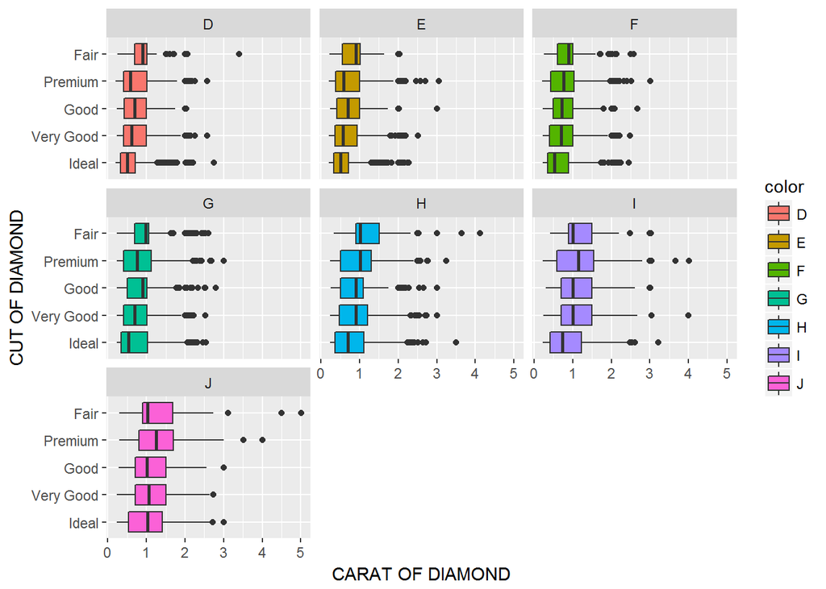

```r
ggplot(data = diamonds, mapping = aes(x = reorder(cut, carat, FUN = median), y = carat, fill=color)) +
  geom_boxplot() +
  labs(x = "CUT OF DIAMOND", y = "CARAT OF DIAMOND") +
  coord_flip() +
  facet_wrap(~color)
```

## Data Munging and Wrangling

### Question 1: Is this data tidy?

#### No, this data is not tidy. Below code will make this tidy.

```r
table2 %>%
  spread(key = type, value = count)
```

```
## # A tibble: 6 x 4
##   country      year  cases population
##   <chr>       <int>  <int>      <int>
## 1 Afghanistan  1999    745   19987071
## 2 Afghanistan  2000   2666   20595360
## 3 Brazil       1999  37737  172006362
## 4 Brazil       2000  80488  174504898
## 5 China        1999 212258 1272915272
## 6 China        2000 213766 1280428583
```

### Question 2: Create a new column called price_per_carat? Do not print the results

#### Here is the code

```r
diamonds %>%
  mutate(price_per_carat = price / carat)
```

### Question 3: How many diamond (and what proportion) have price > 10000 and a carat < 1.5?

#### Answer: 834 diamonds with about 1.54% proportion

```r
diamonds %>%
  mutate(selected = (price > 10000 & carat < 1.5)) %>%
  group_by(selected) %>%
  summarise(n = n()) %>%
  mutate(prop = n/sum(n))
```

```
## # A tibble: 2 x 3
##   selected     n   prop
##   <lgl>    <int>  <dbl>
## 1 FALSE    53106 0.985
## 2 TRUE       834 0.0155
```

#### We just need to be careful of NULL values in the data

## Exploratory Data Analysis (txhousing data)

### Question 1: During what time period is the data from?

```r
txhousing %>%
  summarize(min_year = min(year), min_mo = min(month), max_year = max(year), max_mo = max(month))
```

```
## # A tibble: 1 x 4
##   min_year min_mo max_year max_mo
##      <int>  <int>    <int>  <int>
## 1     2000      1     2015     12
```

### Question 2: How many cities are represented?

#### Answer: 46 cities are represented

```r
txhousing %>%
  count(city)
```

```
## # A tibble: 46 x 2
##    city                      n
##    <chr>                 <int>
##  1 Abilene                 187
##  2 Amarillo                187
##  3 Arlington               187
##  4 Austin                  187
##  5 Bay Area                187
##  6 Beaumont                187
##  7 Brazoria County         187
##  8 Brownsville             187
##  9 Bryan-College Station   187
## 10 Collin County           187
## # ... with 36 more rows
```

### Question 3: Which city, month and year had the highest number of sales?

#### Answer: City = Houston, Month = 7 (July), Year = 2015

```r
txhousing %>%
  filter(sales == max(sales, na.rm = TRUE))
```

```
## # A tibble: 1 x 9
##   city     year month sales     volume median listings inventory  date
##   <chr>   <int> <int> <dbl>      <dbl>  <dbl>    <dbl>     <dbl> <dbl>
## 1 Houston  2015     7  8945 2568156780 217600    23875       3.4 2016.
```

### Question 4: What kind of relationship exists between the number of listings and the number of sales?

#### Answer: In general, as number of listings increases, number of sales is also increasing

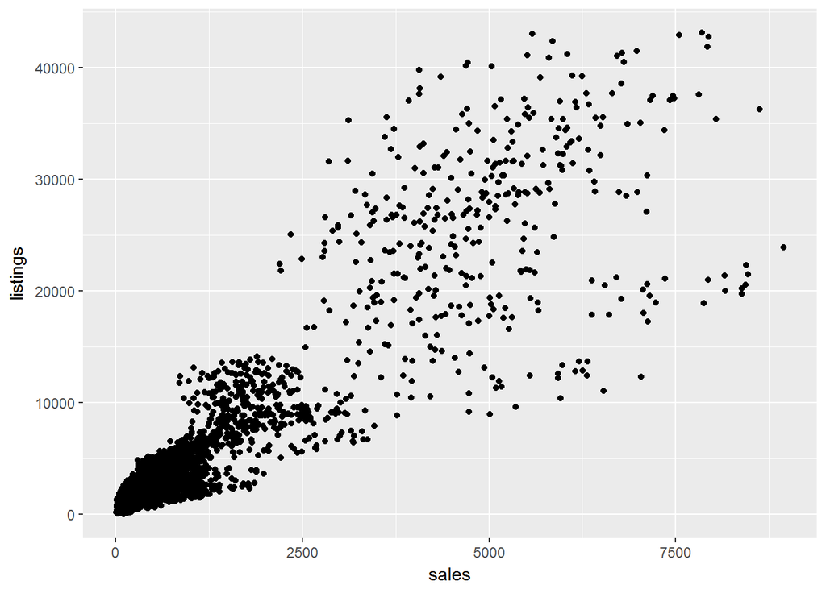

```r
ggplot(data = txhousing, aes(sales, listings)) +
  geom_point()
```

### Question 5: What proportion of sales is missing for each city?

#### Answer: Please see the results of query below

```r
txhousing %>%
  mutate(missed_sales = is.na(sales)) %>%
  group_by(city, missed_sales) %>%
  summarise(count = n()) %>%
  mutate(prop = count / sum(count))
```

```
## # A tibble: 66 x 4
## # Groups:   city [46]
##    city            missed_sales count   prop
##    <chr>           <lgl>        <int>  <dbl>
##  1 Abilene         FALSE          187 1
##  2 Amarillo        FALSE          187 1
##  3 Arlington       FALSE          187 1
##  4 Austin          FALSE          187 1
##  5 Bay Area        FALSE          187 1
##  6 Beaumont        FALSE          187 1
##  7 Brazoria County FALSE          173 0.925
##  8 Brazoria County TRUE            14 0.0749
##  9 Brownsville     FALSE          185 0.989
## 10 Brownsville     TRUE             2 0.0107
## # ... with 56 more rows
```

### Question 6: Look at only the cities and months with greater than 500 sales

```r
txhousing_over500 <- txhousing %>%
  filter(sales > 500)
txhousing_over500
```

```
## # A tibble: 1,883 x 9
##    city       year month sales   volume median listings inventory  date
##    <chr>     <int> <int> <dbl>    <dbl>  <dbl>    <dbl>     <dbl> <dbl>
##  1 Arlington  2000     8   507 60875199 103400     1417       3.5 2001.
##  2 Arlington  2001     5   536 69878959 114400     1592       3.7 2001.
##  3 Arlington  2001     6   534 67744182 108500     1627       3.8 2001.
##  4 Arlington  2001     8   505 65080743 113600     1616       3.7 2002.
##  5 Arlington  2002     5   503 67240236 116100     1741       3.9 2002.
##  6 Arlington  2002     7   509 66954143 119100     1925       4.4 2002.
##  7 Arlington  2003     5   502 67131982 118000     2544       5.9 2003.
##  8 Arlington  2003     7   524 73194692 123500     2799       6.5 2004.
##  9 Arlington  2003     8   531 72397143 123900     2801       6.4 2004.
## 10 Arlington  2004     5   527 72401436 118300     2922       6.5 2004.
## # ... with 1,873 more rows
```

#### 6)a) Are the distributions of the median sales price, when grouped by city, different?

#### Answer: distribution of median sales price is different as per chart below

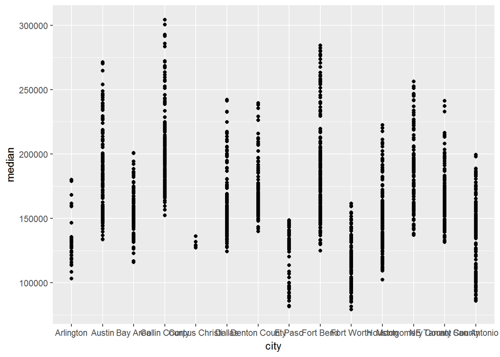

```r
ggplot(data = txhousing_over500, mapping = aes(x = city, y = median)) +
  geom_point()
```

#### 6)b) Any cities that stand out that you’d want to investigate further?

#### Answer: Houston has wide range of sales; Dallas has too many ouliers on the higher median price

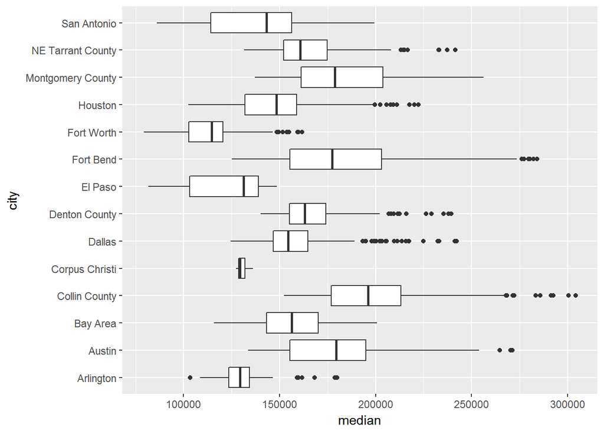

```r
ggplot(data = txhousing_over500, mapping = aes(x = city, y = median)) +
  geom_boxplot() +
  coord_flip()
```

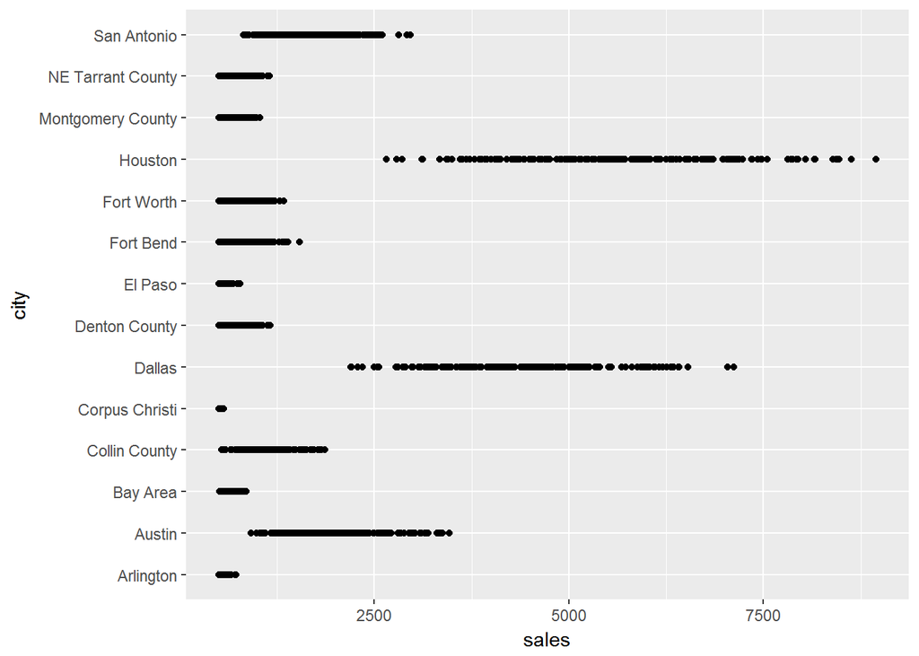

```r
ggplot(data = txhousing_over500, mapping = aes(x = city, y = sales)) +
  geom_point() +
  coord_flip()
```